# Earthquake Alert Level Prediction Using Machine Learning Methods

```python
import pandas as pd
data= pd.read_csv("/Users/misiaszekn/Downloads/earthquake_alert_balanced_dataset.csv")
data.describe()
```

|  | magnitude | depth | cdi | mmi | sig |
| --- | --- | --- | --- | --- | --- |
| count | 1300.000000 | 1300.000000 | 1300.000000 | 1300.000000 | 1300.000000 |
| mean | 7.061008 | 50.321538 | 6.976154 | 6.939231 | -9.749231 |
| std | 0.423738 | 104.348286 | 2.244875 | 1.354774 | 62.245214 |
| min | 6.500000 | 2.000000 | 0.000000 | 1.000000 | -128.000000 |
| 25% | 6.700000 | 12.000000 | 6.000000 | 6.000000 | -54.000000 |
| 50% | 7.000000 | 19.000000 | 8.000000 | 7.000000 | -7.000000 |
| 75% | 7.300000 | 38.000000 | 8.000000 | 8.000000 | 31.000000 |
| max | 8.600000 | 670.000000 | 9.000000 | 9.000000 | 127.000000 |

## Exploratory Data Analysis

The most important thing in the initial analysis of the data we have is to check whether there are duplicates and whether and how extreme outliers exist, which in the case of KNN and SVM methods based on the distances of data from each other, are problematic.

### 1. Missing Values and Duplicates

```python
print("Missing values per column:")
print(data.isnull().sum())

print(f"Number of duplicate rows: {data.duplicated().sum()}")
data_cleaned = data.drop_duplicates()
print(f"Number of duplicate rows in cleaned data: {data_cleaned.duplicated().sum()}")
```

```
Missing values per column:
magnitude    0
depth        0
cdi          0
mmi          0
sig          0
alert        0
dtype: int64
Number of duplicate rows: 44
Number of duplicate rows in cleaned data: 0
```

### 2. Outliers

```python
import numpy as np
numeric_cols = data_cleaned.select_dtypes(include=np.number).columns.tolist()
for col in numeric_cols:
    Q1 = data_cleaned[col].quantile(0.25)
    Q3 = data_cleaned[col].quantile(0.75)
    IQR = Q3 -1
    outliers = data_cleaned[(data_cleaned[col] < Q1 - 1.5*IQR) | (data_cleaned[col] > Q3 + 1.5*IQR)]
    print(f'{col}: {len(outliers)} outliers')
```

```
magnitude: 21 outliers
depth: 166 outliers
cdi: 85 outliers
mmi: 5 outliers
sig: 0 outliers
```

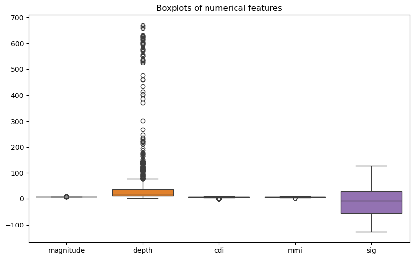

```python
import seaborn as sns
import matplotlib.pyplot as plt

plt.figure(figsize=(10,6))
sns.boxplot(data=data_cleaned[['magnitude', 'depth', 'cdi', 'mmi', 'sig']])
plt.title('Boxplots of numerical features')
plt.show()
```

We observe that outliers appear, but they are most problematic for the depth feature. Therefore, in the case of KNN and SVM, we standardize the variables to ensure that the models generalize well.

## K-Nearest Neighbors (KNN)

### 1. Preparing the data- test and train set

```python
from sklearn.model_selection import train_test_split

features= data_cleaned.drop("alert", axis=1)
outcome= data_cleaned["alert"]

features_train, features_test, outcome_train, outcome_test= train_test_split(features, outcome, test_size= 0.2, random_state= 42, stratify=outcome)
# The records in the dataset we analyze are arranged randomly, so we use the built-in train_test_split function, which divides the data in the proportion of 20 to 80 percent.
# However we need to remember that our classes are not balanced. Therefore we use stratify=outcome above.
```

### 2. Preparing the data- normalization process

```python
from sklearn.preprocessing import StandardScaler

scaler= StandardScaler()

features_train_sc = scaler.fit_transform(features_train)
features_train_sc = pd.DataFrame(features_train_sc, columns=features_train.columns)

features_test_sc = scaler.transform(features_test)
features_test_sc = pd.DataFrame(features_test_sc, columns=features_test.columns)

features_train_sc.describe()
features_test_sc.describe()

#as we checked above the values in each column have sd ap. equals 1 and mean 0, which is exactly the goal we wanted to ahcieve.
```

|  | magnitude | depth | cdi | mmi | sig |
| --- | --- | --- | --- | --- | --- |
| count | 252.000000 | 252.000000 | 252.000000 | 252.000000 | 252.000000 |
| mean | -0.037724 | -0.071493 | 0.013299 | 0.013205 | -0.076178 |
| std | 1.039401 | 0.791261 | 0.985539 | 0.947423 | 1.054759 |
| min | -1.343213 | -0.435224 | -3.088579 | -2.840482 | -1.857791 |
| 25% | -0.866875 | -0.371616 | -0.090684 | -0.663502 | -0.969752 |
| 50% | -0.271451 | -0.308007 | 0.464481 | 0.062158 | 0.007496 |
| 75% | 0.514507 | -0.135354 | 0.464481 | 0.787818 | 0.644127 |
| max | 3.015285 | 5.216873 | 0.908614 | 1.513478 | 2.099861 |

### 3. Construction of the model

```python
import math
from sklearn.neighbors import KNeighborsClassifier
from sklearn.metrics import f1_score, confusion_matrix

# Commonly knon method to choose the proper k is to obtain square root of the number of all observations in train set.
# To avoid ties in the vote, we approximate k to the nearest odd number
k= int(math.sqrt(features_train_sc.shape[0]))
if k%2==0:
    k +=1
print(k)

knn= KNeighborsClassifier(n_neighbors=k)
knn.fit(features_train_sc, outcome_train)

predictions= knn.predict(features_test_sc)
```

```
31
```

### 4. Evaluation Metrics

#### Macro F1

```python
from sklearn.metrics import f1_score
f1_macro= f1_score(outcome_test, predictions, average= 'macro')
print("Macro F1-score:", f1_macro)
```

```
Macro F1-score: 0.7808642600545608
```

#### Confusion Matrix

```python
from sklearn.metrics import confusion_matrix

cm = confusion_matrix(outcome_test, predictions, labels=["green", "yellow", "orange", "red"])


cm_df = pd.DataFrame(cm,
                     index=["True Green", "True Yellow", "True Orange", "True Red"],
                     columns=["Pred Green", "Pred Yellow", "Pred Orange", "Pred Red"])

cm_df
```

|  | Pred Green | Pred Yellow | Pred Orange | Pred Red |
| --- | --- | --- | --- | --- |
| True Green | 46 | 12 | 5 | 2 |
| True Yellow | 1 | 45 | 15 | 3 |
| True Orange | 0 | 2 | 46 | 15 |
| True Red | 0 | 0 | 0 | 60 |

### 5. General conclusions

Taking into consideration Macro F1 metric we are able to conlude thath our model achieves an average Macro F1-score of approximately 0.78 across all alert classes, which is quite good but not perfect. However, Cnofusion Matrix shows that the number of false negative cases, especially in critical situations where the threat is at the red level and the model predicts a different color, is 0 or very, very small- which means that we would receive more false alarms than no warning at all in dramatic situations and that let us judge our model not so critically.

## Gaussian Naive Bayes method

As our data have deinitely continuous type, we choose GaussianNB over MultinomialNB or BernoulliNB.

### 1. Construction of a model

```python
from sklearn.naive_bayes import GaussianNB
nb_model= GaussianNB()

nb_model.fit(features_train, outcome_train)

predictions_nb= nb_model.predict(features_test)
```

### 2. Evaluation Metrics

#### Macro F1

```python
f1_macro_nb = f1_score(outcome_test, predictions_nb, average='macro')
print(f"Macro F1-score (Naive Bayes): {f1_macro_nb:.3f}")
```

```
Macro F1-score (Naive Bayes): 0.659
```

#### Confusion Matrix

```python
cm_nb = confusion_matrix(outcome_test, predictions_nb, labels=["green", "yellow", "orange", "red"])
cm_df_nb = pd.DataFrame(cm_nb,
                        index=["True Green", "True Yellow", "True Orange", "True Red"],
                        columns=["Pred Green", "Pred Yellow", "Pred Orange", "Pred Red"])
cm_df_nb
```

|  | Pred Green | Pred Yellow | Pred Orange | Pred Red |
| --- | --- | --- | --- | --- |
| True Green | 46 | 17 | 1 | 1 |
| True Yellow | 6 | 40 | 10 | 8 |
| True Orange | 1 | 9 | 29 | 24 |
| True Red | 0 | 6 | 2 | 52 |

## Decision Tree Classifier( with entropy)

### 1. Construction of a model

In our first approach, we'll consider a nonparametric model. We won't specify specific values for hyperparameters such as max_depth or min_samples_leaf, thereby demonstrating by plotting a decission tree, how our model overfits.

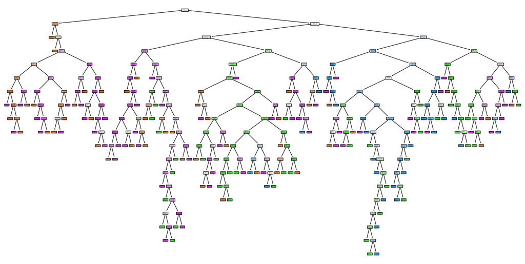

```python
import matplotlib.pyplot as plt
from sklearn.tree import plot_tree


from sklearn.tree import DecisionTreeClassifier

dt_model= DecisionTreeClassifier(criterion= 'entropy', random_state=42)
dt_model.fit(features_train, outcome_train)

predictions_dt= dt_model.predict(features_test)

plt.figure(figsize=(20,10))
plot_tree(
    dt_model,
    feature_names=features_train.columns,
    class_names=dt_model.classes_,
    filled=True
)
plt.show()
```

There's no doubt that the tree is large and difficult to read, so the model is overfitted. We'll now set specific hyperparameters and see how the situation changes in our tree.

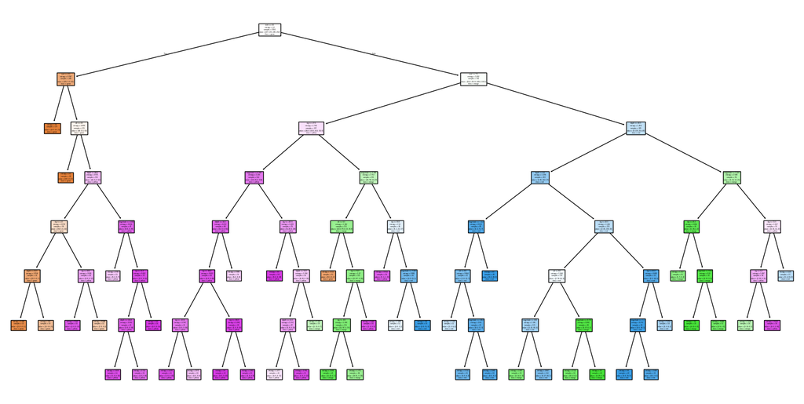

```python
import matplotlib.pyplot as plt
from sklearn.tree import plot_tree
from sklearn.tree import DecisionTreeClassifier

dt_model_hp= DecisionTreeClassifier(criterion= 'entropy',max_depth= 7, min_samples_leaf=10, random_state=42)
dt_model_hp.fit(features_train, outcome_train)

predictions_dt_hp= dt_model_hp.predict(features_test)

plt.figure(figsize=(20,10))
plot_tree(
    dt_model_hp,
    feature_names=features_train.columns,
    class_names=dt_model_hp.classes_,
    filled=True
)
plt.show()
```

The tree seems to be simpler and more readable, but let's check whether we are still dealing with overfitting.

### 2. Overfitting testing

```python
dt_model_hp.score(features_train, outcome_train)
dt_model_hp.score(features_test, outcome_test)
print("Train:", dt_model_hp.score(features_train, outcome_train))
print("Test:", dt_model_hp.score(features_test, outcome_test))
```

```
Train: 0.8276892430278885
Test: 0.8174603174603174
```

It seems that the selected hyperparameters are appropriate, so let's now check the performance of our model using Macro F1 and Confusion Matrix Metrics.